# Часть 1. Проверка гипотезы в Python и составление аналитической записки

Вы предобработали данные в SQL, и теперь они готовы для проверки гипотезы в Python. Загрузите данные пользователей из Москвы и Санкт-Петербурга c суммой часов их активности из файла yandex_knigi_data.csv. Если работаете локально, скачать файл можно по ссылке.

Проверьте наличие дубликатов в идентификаторах пользователей. Сравните размеры групп, их статистики и распределение.

Нулевая гипотеза $H_0: \mu_{\text{СПб}} \leq \mu_{\text{Москва}}$  
Среднее время активности пользователей в Санкт-Петербурге не больше, чем в Москве.

Альтернативная гипотеза $H_1: \mu_{\text{СПб}} > \mu_{\text{Москва}}$  
Среднее время активности пользователей в Санкт-Петербурге больше, и это различие статистически значимо.

По результатам анализа данных подготовьте аналитическую записку, в которой опишите:

Выбранный тип t-теста и уровень статистической значимости.

Результат теста, или p-value.

Вывод на основе полученного p-value, то есть интерпретацию результатов.

Одну или две возможные причины, объясняющие полученные результаты.

- Автор: Стрежнева Вера
- Дата: 22.04.25

## Цели и задачи проекта

Команда сервиса Яндекс Книги изучила данные, полученные при анализе LTV, и выдвинула гипотезу. Она заключается в том, что пользователи, которые приносят больший LTV, являются более лояльными, а значит, проводят в среднем больше времени за чтением и прослушиванием книг в приложении.

Команда предлагает сравнить пользователей из Санкт-Петербурга и Москвы, ведь при расчётах среднего LTV было определено, что эта метрика у петербуржцев выше. Таким образом, гипотеза выглядит так: пользователи из Санкт-Петербурга проводят в среднем больше времени за чтением и прослушиванием книг в приложении по сравнению с пользователями из Москвы.

Цель: проверить эту гипотезу и подготовить аналитическую записку

## Описание данных

Описание данных датафрема yandex_knigi_data.csv:

- `city` - столбец с городом пользователя
- `puid` - столбец с уникальным идентификатором пользователя
- `hours` - столбец с суммарным количеством часов чтения и прослушивания

## Содержимое проекта

1. Загрузка данных и знакомство с ними
2. Проверка гипотезы в Python
3. Аналитическая записка

## 1. Загрузка данных и знакомство с ними

Загрузите данные пользователей из Москвы и Санкт-Петербурга c их активностью (суммой часов чтения и прослушивания) из файла `/datasets/yandex_knigi_data.csv`.

```python
# загрузка библиотек
import pandas as pd
from scipy.stats import ttest_ind
from statsmodels.stats.power import NormalIndPower
from statsmodels.stats.proportion import proportions_ztest
```

```python
# загружаем данные и удаляем лишний столбец, дублирующий индекс
books_data = pd.read_csv('https://code.s3.yandex.net/datasets/yandex_knigi_data.csv')
books_data = books_data.drop('Unnamed: 0', axis=1)
books_data
```

|  | city | puid | hours |
| --- | --- | --- | --- |
| 0 | Москва | 9668 | 26.167776 |
| 1 | Москва | 16598 | 82.111217 |
| 2 | Москва | 80401 | 4.656906 |
| 3 | Москва | 140205 | 1.840556 |
| 4 | Москва | 248755 | 151.326434 |
| ... | ... | ... | ... |
| 8779 | Санкт-Петербург | 1130000028554332 | 4.107774 |
| 8780 | Санкт-Петербург | 1130000030307246 | 45.069222 |
| 8781 | Санкт-Петербург | 1130000038726322 | 0.211944 |
| 8782 | Санкт-Петербург | 1130000047892100 | 4.311841 |
| 8783 | Санкт-Петербург | 1130000061443598 | 20.847222 |

8784 rows × 3 columns

Посмотрим, есть ли в данных пропуски и дубликаты:

```python
books_data.info()
```

```
<class 'pandas.core.frame.DataFrame'>
RangeIndex: 8784 entries, 0 to 8783
Data columns (total 3 columns):
 #   Column  Non-Null Count  Dtype
---  ------  --------------  -----
 0   city    8784 non-null   object
 1   puid    8784 non-null   int64
 2   hours   8784 non-null   float64
dtypes: float64(1), int64(1), object(1)
memory usage: 206.0+ KB
```

Видим, что пропусков нет.

Проверяем дубликаты:

```python
# смотрим явные дубликаты
books_data.duplicated().sum()
```

```
0
```

```python
#смотрим дубликаты в идентификаторе пользователя
books_data['puid'].duplicated().sum()
```

```
244
```

```python
#удалим имеющиеся дубликаты
books_data = books_data.drop_duplicates(subset='puid')
books_data
```

|  | city | puid | hours |
| --- | --- | --- | --- |
| 0 | Москва | 9668 | 26.167776 |
| 1 | Москва | 16598 | 82.111217 |
| 2 | Москва | 80401 | 4.656906 |
| 3 | Москва | 140205 | 1.840556 |
| 4 | Москва | 248755 | 151.326434 |
| ... | ... | ... | ... |
| 8778 | Санкт-Петербург | 1130000027468068 | 5.879444 |
| 8780 | Санкт-Петербург | 1130000030307246 | 45.069222 |
| 8781 | Санкт-Петербург | 1130000038726322 | 0.211944 |
| 8782 | Санкт-Петербург | 1130000047892100 | 4.311841 |
| 8783 | Санкт-Петербург | 1130000061443598 | 20.847222 |

8540 rows × 3 columns

Теперь проверим столбец `hours` на аномалии и выбросы

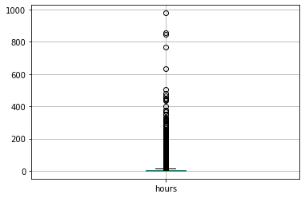

```python
books_data.boxplot(column='hours')
```

Видим, что выбросы есть. Они могут исказить картину при проведении статистических тестов, поэтому отсечем данные по 99 квантилю

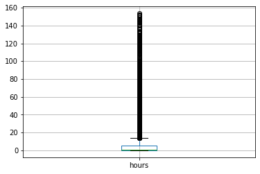

```python
books_data_2 = books_data[books_data['hours']<books_data['hours'].quantile(0.99)]
books_data_2.boxplot(column='hours')
```

Для удобства выделим пользователей из Москвы и Санкт-Петербурга в отдельные датафреймы

```python
moscow = books_data_2[books_data_2['city']=='Москва']
spb = books_data_2[books_data_2['city']=='Санкт-Петербург']
```

Сравним в этих группах размеры выборок и проверим на пересечение

```python
print(f'Размер группы пользователей из Москвы: {moscow.shape[0]}')
print(f'Размер группы пользователей из Санкт-Петербурга: {spb.shape[0]}')
```

```
Размер группы пользователей из Москвы: 6170
Размер группы пользователей из Санкт-Петербурга: 2284
```

Разница в размере выборок большая: почти в 3 раза. Это может исказить дальнейшие результаты.

Проверяем на пересечение:

```python
list(set(moscow['puid']) & set(spb['puid']))
```

```
[]
```

Пересечений нет, значит можно проводить тест.

Посмотрим также на статистики групп и распределение часов чтения и прослушивания:

```python
moscow['hours'].describe()
```

```
count    6170.000000
mean        8.083464
std        19.748368
min         0.000018
25%         0.058377
50%         0.888748
75%         5.655006
max       153.639891
Name: hours, dtype: float64
```

```python
spb['hours'].describe()
```

```
count    2284.000000
mean        8.377901
std        19.723539
min         0.000025
25%         0.057032
50%         0.852310
75%         5.672186
max       152.338086
Name: hours, dtype: float64
```

Заметно, что хоть данных в Московской группе больше, но среднее значение, стандартное отклонение и другие статистики довольно близки друг к другу в обеих группах.

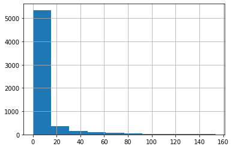

```python
moscow['hours'].hist()
```

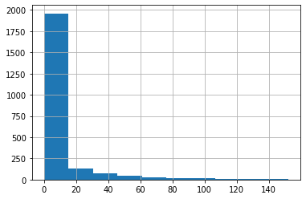

```python
spb['hours'].hist()
```

Исходные распределения часов чтения и прослушивания также схожи между собой в группах.

**Выводы:**

- пропусков в данных нет
- явных дубликатов нет
- удалили 244 дубликата в столбце с id пользователей
- очистили данные от выбросов по 99 квантилю
- данные распредлены неравномерно, примерно в соотношении 70:30
- пересечений между группами нет
- статистики групп и распределения исходных данных почти одинаковы

## 2. Проверка гипотезы в Python

Гипотеза звучит так: пользователи из Санкт-Петербурга проводят в среднем больше времени за чтением и прослушиванием книг в приложении, чем пользователи из Москвы. Попробуйте статистически это доказать, используя одностороннюю проверку гипотезы с двумя выборками:

- Нулевая гипотеза H₀: Средняя активность пользователей в часах в Санкт-Петербурге не больше, чем в Москве. *(исправлено с "равны")*
- Альтернативная гипотеза H₁: Средняя активность пользователей в Санкт-Петербурге больше, и это различие статистически значимо.

Будем использовать t-тест Уэлча, так как у нас нет информации о равенстве дисперсии, а также из-за выбросов в данных. Уровень значимости возьмем 0.05

```python
# выделяем нужные данные для теста
moscow_hours = moscow['hours']
spb_hours = spb['hours']

# Проведение теста Уэлча
t_stat, p_value = ttest_ind(moscow_hours, spb_hours, equal_var=False, alternative='less')

print(f"p-value: {p_value}")

alpha = 0.05
if p_value < alpha:
    print("Нулевая гипотеза отвергается. Пользователи из Санкт-Петербурга проводят больше времени за чтением и прослушиванием книг.")
else:
    print("Не можем отвергнуть нулевую гипотезу о том, что активность в Санкт-Петербурге меньше или равна активности в Москве")
```

```
p-value: 0.2711852459663646
Не можем отвергнуть нулевую гипотезу о том, что активность в Санкт-Петербурге меньше или равна активности в Москве
```

## 3. Аналитическая записка

По результатам анализа данных подготовьте аналитическую записку, в которой опишете:

- Выбранный тип t-теста и уровень статистической значимости.
- Результат теста, или p-value.
- Вывод на основе полученного p-value, то есть интерпретацию результатов.
- Одну или две возможные причины, объясняющие полученные результаты.

**Выводы:**

- для тестирования был выбран t-тест Уэлча, т.к. он позволяет работать с неоднородными выборками, без равенства дисперсий
- уровень статистической значимости был выбран стандартно - 0.05
- в результате получили значение p-value=0.27, что больше уровня значимости
- отвергнуть нулевую гипотезу о том, что пользователи из Санкт-Петербурга активны не более, чем пользователи из Москвы, нельзя (т.к p-value больше уровня значимости)
- к такому результату могла привести изначальная несбалансированность данных, которую мы увидели при предварительном анализе (данных из Москвы в 3 раза больше)

# Часть 2. Анализ результатов A/B-тестирования

Теперь вам нужно проанализировать другие данные. Представьте, что к вам обратились представители интернет-магазина BitMotion Kit, в котором продаются геймифицированные товары для тех, кто ведёт здоровый образ жизни. У него есть своя целевая аудитория, даже появились хиты продаж: эспандер со счётчиком и напоминанием, так и подстольный велотренажёр с Bluetooth.

В будущем компания хочет расширить ассортимент товаров. Но перед этим нужно решить одну проблему. Интерфейс онлайн-магазина слишком сложен для пользователей — об этом говорят отзывы.

Чтобы привлечь новых клиентов и увеличить число продаж, владельцы магазина разработали новую версию сайта и протестировали его на части пользователей. По задумке, это решение доказуемо повысит количество пользователей, которые совершат покупку.

Ваша задача — провести оценку результатов A/B-теста. В вашем распоряжении:

- данные о действиях пользователей и распределении их на группы,
- техническое задание.

Оцените корректность проведения теста и проанализируйте его результаты.

## 1. Опишите цели исследования.

Чтобы привлечь новых клиентов и увеличить число продаж, владельцы магазина разработали новую версию сайта и протестировали его на части пользователей. По задумке, это решение доказуемо повысит количество пользователей, которые совершат покупку.

Цель: оценить корректность проведения теста и проанализировать его результаты.

## 2. Загрузите данные, оцените их целостность.

```python
participants = pd.read_csv('https://code.s3.yandex.net/datasets/ab_test_participants.csv')
events = pd.read_csv('https://code.s3.yandex.net/datasets/ab_test_events.zip',
                     parse_dates=['event_dt'], low_memory=False)
```

```python
participants
```

|  | user_id | group | ab_test | device |
| --- | --- | --- | --- | --- |
| 0 | 0002CE61FF2C4011 | B | interface_eu_test | Mac |
| 1 | 001064FEAAB631A1 | B | recommender_system_test | Android |
| 2 | 001064FEAAB631A1 | A | interface_eu_test | Android |
| 3 | 0010A1C096941592 | A | recommender_system_test | Android |
| 4 | 001E72F50D1C48FA | A | interface_eu_test | Mac |
| ... | ... | ... | ... | ... |
| 14520 | FFE7FC140521F5F6 | A | interface_eu_test | PC |
| 14521 | FFEFC0E55C1CCD4F | A | interface_eu_test | PC |
| 14522 | FFF28D02B1EACBE1 | B | recommender_system_test | PC |
| 14523 | FFF28D02B1EACBE1 | B | interface_eu_test | PC |
| 14524 | FFF58BC33966EB51 | A | interface_eu_test | Android |

14525 rows × 4 columns

```python
participants.info()
```

```
<class 'pandas.core.frame.DataFrame'>
RangeIndex: 14525 entries, 0 to 14524
Data columns (total 4 columns):
 #   Column   Non-Null Count  Dtype
---  ------   --------------  -----
 0   user_id  14525 non-null  object
 1   group    14525 non-null  object
 2   ab_test  14525 non-null  object
 3   device   14525 non-null  object
dtypes: object(4)
memory usage: 454.0+ KB
```

Можно предположить, что в таблице содержатся данные по нескольким А/Б тестам. Нам понадобятся в дальнейшем данные с ab_test=interface_eu_test, так как нас просили проверить тест с изменением интерфейса сайта.

Пропусков в данных нет. Можно проверить на явные дубликаты. А также на дубликаты по айди и виду теста одновременно.

```python
participants.duplicated().sum()
```

```
0
```

```python
participants[['user_id', 'ab_test']].duplicated().sum()
```

```
0
```

Таким образом, в таблице `participants` пропусков нет и дубликатов нет.

Проверим следующую таблицу

```python
events
```

|  | user_id | event_dt | event_name | details |
| --- | --- | --- | --- | --- |
| 0 | GLOBAL | 2020-12-01 00:00:00 | End of Black Friday Ads Campaign | ZONE_CODE15 |
| 1 | CCBE9E7E99F94A08 | 2020-12-01 00:00:11 | registration | 0.0 |
| 2 | GLOBAL | 2020-12-01 00:00:25 | product_page | NaN |
| 3 | CCBE9E7E99F94A08 | 2020-12-01 00:00:33 | login | NaN |
| 4 | CCBE9E7E99F94A08 | 2020-12-01 00:00:52 | product_page | NaN |
| ... | ... | ... | ... | ... |
| 787281 | 1A655C280B064708 | 2020-12-31 23:57:44 | product_page | NaN |
| 787282 | B77B2F4BCA134618 | 2020-12-31 23:58:23 | registration | 0.0 |
| 787283 | GLOBAL | 2020-12-31 23:58:30 | product_cart | NaN |
| 787284 | B12AD1623E494FAD | 2020-12-31 23:58:34 | registration | -6.52 |
| 787285 | 5456977474344433 | 2020-12-31 23:59:48 | registration | -3.67 |

787286 rows × 4 columns

```python
events.info()
```

```
<class 'pandas.core.frame.DataFrame'>
RangeIndex: 787286 entries, 0 to 787285
Data columns (total 4 columns):
 #   Column      Non-Null Count   Dtype
---  ------      --------------   -----
 0   user_id     787286 non-null  object
 1   event_dt    787286 non-null  datetime64[ns]
 2   event_name  787286 non-null  object
 3   details     249022 non-null  object
dtypes: datetime64[ns](1), object(3)
memory usage: 24.0+ MB
```

```python
events.duplicated().sum()
```

```
36318
```

Пропуски есть в столбце с деталями, скорее всего это особенности сбора данных, не будем с ними ничего делать. Явных дубликатов 36318, их можно удалить.

```python
events = events.drop_duplicates()
```

## 3. По таблице `ab_test_participants` оцените корректность проведения теста:

3.1 Выделите пользователей, участвующих в тесте, и проверьте:

- соответствие требованиям технического задания,
- равномерность распределения пользователей по группам теста,
- отсутствие пересечений с конкурирующим тестом (нет пользователей, участвующих одновременно в двух тестовых группах).

Снчачала посмотрим пересечение пользователей в группах B в двух тестах, чтобы не было такого, что человек видел и то, и другое изменение.

```python
inter = list(set(participants[(participants['ab_test']=='interface_eu_test') & (participants['group']=='B')]['user_id']) & set(participants[(participants['ab_test']=='recommender_system_test') & (participants['group']=='B')]['user_id']))
print(inter)
print(len(inter))
print(len(inter)/participants['user_id'].nunique()*100)
```

```
['C33D8C1C81C7AA23', 'FEA0C585A53E7027', 'BEF16764A13AEC34', '7D8970118A695D48', '30DEB75B33B92DC8', 'A6E6ECF8E4924633', '0C2E77C6A381704A', '84AAB026310D49C4', '8FC9D1BB3017BE66', '886E52074D084B18', 'EAFB9027A27D510C', '88FB1EDF3E249223', '6B72CFAE1935C789', '23F551153080EBAB', '82F72EC6CDC1BA8F',…
116
0.850564598914797
```

Видим, что встречаются пользователи, которые находятся в двух тестовых группах. Это может исказить дальнейшие выводы при проведении теста, поэтому удалим их, тем более они составляюти менее 1 процента от всех пользователей.

```python
participants = participants[~participants['user_id'].isin(inter)]
```

```python
# выделяем строки с проводимым тестом
ab_test_participants = participants[participants['ab_test']=='interface_eu_test']
```

```python
# смотрим пересечение между группами
list(set(ab_test_participants[ab_test_participants['group']=='A']['user_id']) & set(ab_test_participants[ab_test_participants['group']=='B']['user_id']))
```

```
[]
```

```python
print(f"Размер контрольной группы: {ab_test_participants[ab_test_participants['group']=='A'].shape[0]}")
print(f"Размер тестовой группы: {ab_test_participants[ab_test_participants['group']=='B'].shape[0]}")
```

```
Размер контрольной группы: 5383
Размер тестовой группы: 5351
```

Таким образом, пользователей, которые одновременно в одной группе, нет. Размеры выборок сопоставимы - 5383 и 5351.

3.2 Проанализируйте данные о пользовательской активности по таблице `ab_test_events`:

- оставьте только события, связанные с участвующими в изучаемом тесте пользователями;

```python
ab_test_events = events[events['user_id'].isin(ab_test_participants['user_id'].unique())]
```

- определите горизонт анализа: рассчитайте время (лайфтайм) совершения события пользователем после регистрации и оставьте только те события, которые были выполнены в течение первых семи дней с момента регистрации;

Сначала выделим зарегистрированных пользователей и дату их регистрации:

```python
ab_test_reg = ab_test_events[ab_test_events['event_name']=='registration'][['user_id', 'event_dt']]
ab_test_reg = ab_test_reg.rename({'event_dt':'reg_date'}, axis=1)
ab_test_reg
```

|  | user_id | reg_date |
| --- | --- | --- |
| 64672 | 5F506CEBEDC05D30 | 2020-12-06 14:10:01 |
| 64946 | 51278A006E918D97 | 2020-12-06 14:37:25 |
| 66585 | A0C1E8EFAD874D8B | 2020-12-06 17:20:22 |
| 67873 | 275A8D6254ACF530 | 2020-12-06 19:36:54 |
| 67930 | 0B704EB2DC7FCA4B | 2020-12-06 19:42:20 |
| ... | ... | ... |
| 654517 | 52B5A81EFC31AF1D | 2020-12-23 23:44:45 |
| 654518 | B1D88FBD4BA58E1B | 2020-12-23 23:44:47 |
| 654581 | 38CA3A3C4FE3FEFD | 2020-12-23 23:47:47 |
| 654640 | 16CCB1C8C4DCF1AF | 2020-12-23 23:50:29 |
| 680872 | 2DDC948BD76ABC57 | 2020-12-24 21:57:10 |

10734 rows × 2 columns

Теперь объединим полученный датафрейм с датафреймом с событиями

```python
ab_events = ab_test_events.merge(ab_test_reg, how='inner', on='user_id')
ab_events
```

|  | user_id | event_dt | event_name | details | reg_date |
| --- | --- | --- | --- | --- | --- |
| 0 | 5F506CEBEDC05D30 | 2020-12-06 14:10:01 | registration | 0.0 | 2020-12-06 14:10:01 |
| 1 | 5F506CEBEDC05D30 | 2020-12-07 01:25:14 | login | NaN | 2020-12-06 14:10:01 |
| 2 | 5F506CEBEDC05D30 | 2020-12-07 01:25:47 | login | NaN | 2020-12-06 14:10:01 |
| 3 | 5F506CEBEDC05D30 | 2020-12-09 12:40:49 | login | NaN | 2020-12-06 14:10:01 |
| 4 | 5F506CEBEDC05D30 | 2020-12-09 12:40:49 | product_page | NaN | 2020-12-06 14:10:01 |
| ... | ... | ... | ... | ... | ... |
| 72930 | 16CCB1C8C4DCF1AF | 2020-12-23 23:50:29 | registration | 0.0 | 2020-12-23 23:50:29 |
| 72931 | 16CCB1C8C4DCF1AF | 2020-12-23 23:55:52 | login | NaN | 2020-12-23 23:50:29 |
| 72932 | 2DDC948BD76ABC57 | 2020-12-24 21:57:10 | registration | -4.29 | 2020-12-24 21:57:10 |
| 72933 | 2DDC948BD76ABC57 | 2020-12-24 21:58:49 | login | NaN | 2020-12-24 21:57:10 |
| 72934 | 2DDC948BD76ABC57 | 2020-12-24 22:00:40 | product_page | NaN | 2020-12-24 21:57:10 |

72935 rows × 5 columns

Теперь посчитаем lifetime и оставим события в первую неделю после регистрации

```python
ab_events['lifetime'] = (ab_events['event_dt']-ab_events['reg_date']).dt.days
first_week = ab_events[ab_events['lifetime'] < 7]
first_week.info()
```

```
<class 'pandas.core.frame.DataFrame'>
Int64Index: 62934 entries, 0 to 72934
Data columns (total 6 columns):
 #   Column      Non-Null Count  Dtype
---  ------      --------------  -----
 0   user_id     62934 non-null  object
 1   event_dt    62934 non-null  datetime64[ns]
 2   event_name  62934 non-null  object
 3   details     16969 non-null  object
 4   reg_date    62934 non-null  datetime64[ns]
 5   lifetime    62934 non-null  int64
dtypes: datetime64[ns](2), int64(1), object(3)
memory usage: 3.4+ MB
```

Оцените достаточность выборки для получения статистически значимых результатов A/B-теста. Заданные параметры:

- базовый показатель конверсии — 30%,
- мощность теста — 80%,
- достоверность теста — 95%.

Проверим, используя калькулятор Эвана Миллера. Получилось, что на каждую группу надо 3692 записей. У нас значительно больше, значит все нормально.

- рассчитайте для каждой группы количество посетителей, сделавших покупку, и общее количество посетителей.

Сначала объединим датафреймы с участниками и с событиями

```python
test = ab_test_participants.merge(first_week, how='inner', on='user_id')
test
```

|  | user_id | group | ab_test | device | event_dt | event_name | details | reg_date | lifetime |
| --- | --- | --- | --- | --- | --- | --- | --- | --- | --- |
| 0 | 0002CE61FF2C4011 | B | interface_eu_test | Mac | 2020-12-07 04:37:31 | registration | -2.38 | 2020-12-07 04:37:31 | 0 |
| 1 | 0002CE61FF2C4011 | B | interface_eu_test | Mac | 2020-12-07 04:37:49 | login | NaN | 2020-12-07 04:37:31 | 0 |
| 2 | 0002CE61FF2C4011 | B | interface_eu_test | Mac | 2020-12-07 04:37:57 | login | NaN | 2020-12-07 04:37:31 | 0 |
| 3 | 0002CE61FF2C4011 | B | interface_eu_test | Mac | 2020-12-07 04:38:54 | login | NaN | 2020-12-07 04:37:31 | 0 |
| 4 | 0002CE61FF2C4011 | B | interface_eu_test | Mac | 2020-12-08 22:15:35 | login | NaN | 2020-12-07 04:37:31 | 1 |
| ... | ... | ... | ... | ... | ... | ... | ... | ... | ... |
| 62929 | FFEFC0E55C1CCD4F | A | interface_eu_test | PC | 2020-12-13 23:52:15 | registration | 0.0 | 2020-12-13 23:52:15 | 0 |
| 62930 | FFEFC0E55C1CCD4F | A | interface_eu_test | PC | 2020-12-13 23:52:22 | login | NaN | 2020-12-13 23:52:15 | 0 |
| 62931 | FFF58BC33966EB51 | A | interface_eu_test | Android | 2020-12-13 17:37:34 | registration | -0.45 | 2020-12-13 17:37:34 | 0 |
| 62932 | FFF58BC33966EB51 | A | interface_eu_test | Android | 2020-12-13 17:56:02 | login | NaN | 2020-12-13 17:37:34 | 0 |
| 62933 | FFF58BC33966EB51 | A | interface_eu_test | Android | 2020-12-17 03:21:02 | login | NaN | 2020-12-13 17:37:34 | 3 |

62934 rows × 9 columns

```python
purch_A = test[(test['group']=='A') & (test['event_name']=='purchase')]['user_id'].nunique()
purch_B = test[(test['group']=='B') & (test['event_name']=='purchase')]['user_id'].nunique()
A_group = test[(test['group']=='A')]['user_id'].nunique()
B_group = test[(test['group']=='B')]['user_id'].nunique()
print(f'В группе А покупку совершили: {purch_A} пользователей')
print(f'В группе А всего: {A_group} пользователей')
print(f'В группе Б покупку совершили: {purch_B} пользователей')
print(f'В группе Б всего: {B_group} пользователей')
```

```
В группе А покупку совершили: 1480 пользователей
В группе А всего: 5383 пользователей
В группе Б покупку совершили: 1579 пользователей
В группе Б всего: 5351 пользователей
```

- сделайте предварительный общий вывод об изменении пользовательской активности в тестовой группе по сравнению с контрольной.

```python
print(f'В группе А конверсия из регистрации в покупку: {purch_A/A_group*100}%')
print(f'В группе Б конверсия из регистрации в покупку: {purch_B/B_group*100}%')
print(f'Конверсия изменилась так: {purch_B/B_group*100-purch_A/A_group*100}')
```

```
В группе А конверсия из регистрации в покупку: 27.493962474456623%
В группе Б конверсия из регистрации в покупку: 29.508503083535786%
Конверсия изменилась так: 2.0145406090791624
```

Предварительно, хоть конверсия и увеличилась, в гипотезе было условие ее увеличение минимум на 3 процентных пункта, а мы имеем 2.01%. Осталось проверить статистическую значимость изменений.

## 4. Проведите оценку результатов A/B-тестирования:

- Проверьте изменение конверсии подходящим статистическим тестом, учитывая все этапы проверки гипотез.

H1: упрощение интерфейса приведёт к тому, что в течение семи дней после регистрации в системе конверсия зарегистрированных пользователей в покупателей увеличится как минимум на три процентных пункта.

Уровень значимости ставим 0.05

```python
# проводим тест
alpha = 0.05
stats_ztest, pvalue_ztest = proportions_ztest([purch_A, purch_B], [A_group, B_group], alternative='smaller')
if pvalue_ztest<alpha:
    print(f'Нулевая гипотеза отвергается, pvalue={pvalue_ztest}')
else:
    print(f'Не можем отвергнуть нулевую гипотезу, pvalue={pvalue_ztest}')
```

```
Нулевая гипотеза отвергается, pvalue=0.010393282955333764
```

- Опишите выводы по проведённой оценке результатов A/B-тестирования. Что можно сказать про результаты A/B-тестирования? Был ли достигнут ожидаемый эффект в изменении конверсии?